# PowerPuffGenes Report

2025-03-17

# Introduction

Understanding the temporal dynamics of gene expression is crucial for deciphering complex biological processes like stem cell differentiation or response to stimuli. This project utilizes a doxycycline (dox)-inducible system in mouse stem cells, where dox triggers gene expression via the rtTA-TRE mechanism. While powerful, concerns exist that dox itself might exert off-target effects on the transcriptome. Leveraging Dr. Rinn’s lab RNA-seq dataset spanning five time points (0, 12, 24, 48, 96 hours) with replicates, this analysis aims to: 1) Identify genes significantly regulated following dox administration. 2) Characterize the temporal profiles of these regulated genes, distinguishing between transient and sustained responses. 3) Investigate the role, significance, and chromosomal location of these genes. We employ the nf-core/rnaseq pipeline for data processing and DESeq2 for differential expression analysis, providing a practical application of bioinformatics skills to time-course data exploration.

# RNA sequence analysis

## nf-core/rnaseq Pipeline

The raw sequencing reads were processed using the [nf-core/rnaseq pipeline](https://nf-co.re/rnaseq) version 3.14, a standardized and reproducible bioinformatics pipeline built using [Nextflow](https://www.nextflow.io/).

Pipeline diagram:

[figure not shown]

[figure not shown]

nf-core/rnaseq diagram

### Key Input/Output Files

- **Input:** Raw FASTQ files (paired-end reads recommended) and a sample sheet defining the experimental design (samples, conditions, replicates).
- **Output:** The pipeline generates numerous output files. Key files used in this analysis include:
  - `salmon.merged.gene_counts.tsv`: Raw gene-level counts estimated by Salmon. Used as input for DESeq2 statistical modeling.
  - `salmon.merged.gene_tpm.tsv`: Gene-level Transcripts Per Million (TPM) values. Used for expression level interpretation and visualization, as TPM is normalized for gene length and sequencing depth.
  - `multiqc/multiqc_report.html`: An aggregated quality control report across all samples.
  - Alignment files (BAM format): Detailed mapping results (not directly used in this DE analysis but available).

# Differential Expression Analysis

## Proccesing and analysis of count and tpm data

### Parameters and paths definition

```r
COUNTS_PATH      <- "data/NF3-18/salmon.merged.gene_counts.tsv"
TPM_PATH         <- "data/NF3-18/salmon.merged.gene_tpm.tsv"
FILTER_TRESHOLD  <- 0
P_VALUE_FILTER   <- 0.05
LOG2_FOLD_FILTER <- 1
```

### Loading and preproccesing count and tpm files

```r
# Read raw data and make dictionary mapping gene id with gene name
counts_orig  <- read.table(COUNTS_PATH, header=TRUE, row.names=1)
tpm_orig     <- read.table(TPM_PATH, header=TRUE, row.names=1)
g2s          <- data.frame(gene_id = rownames(counts_orig),
                           gene_name = counts_orig[ , 1])

# Remove gene name column from counts and convert counts to numerical rounded matrix
counts           <- counts_orig %>% select(-gene_name)
tpm              <- tpm_orig %>% select(-gene_name)
counts_matrix    <- as.matrix(counts)
counts_matrix    <- round(counts_matrix)

# Filter genes with no counts for any of the samples
counts_filtered  <- counts_matrix[rowSums(counts_matrix) > FILTER_TRESHOLD, ]
tpm_filtered     <- tpm[rowSums(tpm) > FILTER_TRESHOLD, ]


save(counts, tpm, counts_filtered, tpm_filtered, g2s, file = "results/data_files.RData")
```

### DESeq2 analysis for counts

```r
# Make a column from the titles of the columns of the counts_matrix table
deseq_samples  <- data.frame(sample_id = colnames(counts))

# Get the time and replicate values from the sample names in deseq_samples
split_values     <- strsplit(deseq_samples$sample_id, "_")
time_values      <- sapply(split_values, function(x) x[[2]])
replicate_values <- sapply(split_values, function(x) x[[3]])

# Add time and replicate values as columns to deseq_samples and factor them
deseq_samples$time_point <- time_values
deseq_samples$replicate  <- replicate_values
deseq_samples$time_point <- factor(deseq_samples$time_point, levels=c("0","12","24","48","96"))
deseq_samples$replicate  <- factor(deseq_samples$replicate)

# Testing whether sample sheet and counts are arranged properly
stopifnot(all(colnames(counts) == rownames(deseq_samples$sample_id)))

# Prepare DESeq dataset and run DESea2
dds <- DESeqDataSetFromMatrix(countData = counts_filtered,
                              colData = deseq_samples,
                              design = ~ time_point)
dds <- DESeq(dds)
```

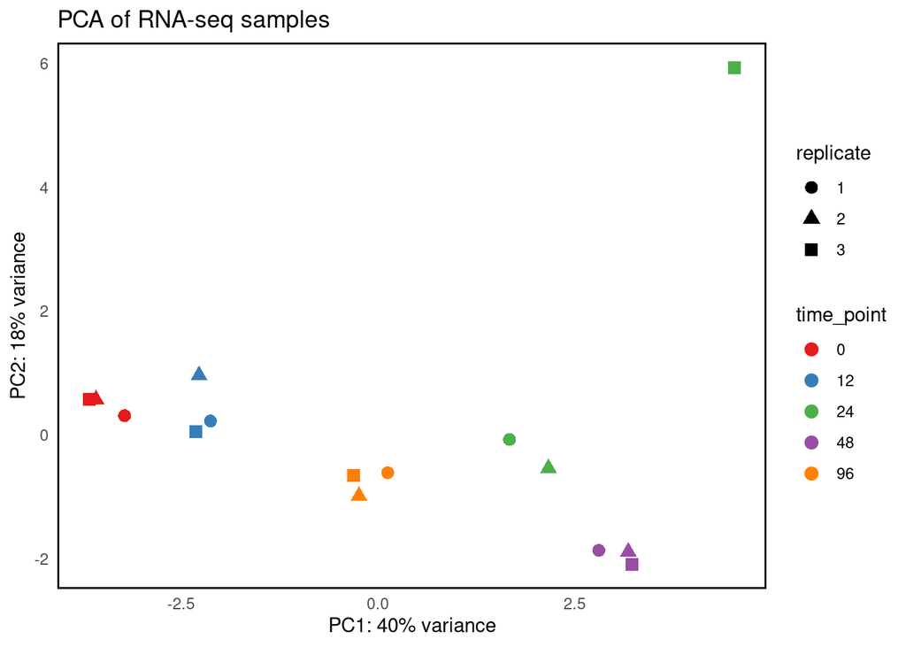

```r
# PCA plot function
plot_pca <- function(dds, intgroup="time_point", ntop=500) {
  vsd <- vst(dds, blind=FALSE) # Get variance stabilized data
  pca_data <- plotPCA(vsd, intgroup=intgroup, returnData=TRUE, ntop=ntop) # Run PCA
  percentVar <- round(100 * attr(pca_data, "percentVar")) # Percentage of variance explained
  # Plot
  ggplot(pca_data, aes(x=PC1, y=PC2, color=time_point, shape=replicate)) +
    geom_point(size=3) +
    xlab(paste0("PC1: ", percentVar[1], "% variance")) +
    ylab(paste0("PC2: ", percentVar[2], "% variance")) +
    ggtitle("PCA of RNA-seq samples") +
    theme_minimal() +
    theme(
      panel.grid.major = element_blank(),
      panel.grid.minor = element_blank(),
      panel.border = element_rect(color = "black", fill = NA, linewidth = 1)
    ) +
    scale_color_brewer(palette = "Set1")
}

pca_plot <- plot_pca(dds, intgroup=c("time_point", "replicate"))
print(pca_plot)
```

```r
ggsave("results/pca_plot.png", pca_plot, width = 8, height = 6, dpi = 300)
```

### Obtaining and filtering count results

```r
# Define the comparisons
comparison_list <- list(
  # Time points against baseline
  time_12_vs_0 = c("time_point", "12", "0"),
  time_24_vs_0 = c("time_point", "24", "0"),
  time_48_vs_0 = c("time_point", "48", "0"),
  time_96_vs_0 = c("time_point", "96", "0"),
  # Time series comparisons
  time_24_vs_12 = c("time_point", "24", "12"),
  time_48_vs_24 = c("time_point", "48", "24"),
  time_96_vs_48 = c("time_point", "96", "48")
)

# Create empty df to store results values (schema looks good)
results <- data.frame("gene_id" = character(),
                      "baseMean" = numeric(),
                      "log2FoldChange" = numeric(),
                      "lfcSE" = numeric(),
                      "stat" = numeric(),
                      "pvalue" = numeric(),
                      "padj" = numeric(),
                      "gene_name" = character(),
                      "comparison" = character())

# Loop through the defined contrasts
for(i in names(comparison_list)) {
  current_comparison <- comparison_list[[i]] # get comparison i
  res <- results(dds, contrast = current_comparison) # get results for time comparison i using 'contrast'
  if (is.null(res)) {
      warning(paste("Could not generate results for contrast:", contrast_name))
      next}
  # Temporary df to store the results for comparison i
  tmp_res_df <- res %>%
    as.data.frame() %>%
    rownames_to_column("gene_id") %>%
    merge(g2s, by = "gene_id", all.x = TRUE) %>%
    mutate(comparison = i)
  # Add the temporary df to the main results df
  results <- bind_rows(results, tmp_res_df)
}

# Filter based on p-value at log2fold chanes defined at top
filtered_results <- results %>%
  filter(padj < P_VALUE_FILTER, abs(log2FoldChange) > LOG2_FOLD_FILTER)

# Get all gene names that are significant (drop gene name repetitions)
filtered_genes <- as.data.frame(filtered_results$gene_name, collapse = "\n")
filtered_genes <- unique(filtered_genes)
colnames(filtered_genes)[1] <- "gene_name"

save(results, filtered_results, filtered_genes, file = "results/results_counts.RData")
```

### Obtaining tmp results

```r
# Loop to calculate avg and sd for replicates at a given time point
time_points <- c("0", "12", "24", "48", "96")
avg_and_sd_values <- list()
for (tp in time_points) {
  cols     <- grep(paste0("WT_", tp, "_"), colnames(tpm_filtered))
  avg      <- rowMeans(tpm_filtered[, cols])
  sd       <- apply(tpm_filtered[, cols], 1, sd)
  sd       <- data.frame(sd)
  combined <- cbind(avg, sd)
  avg_and_sd_values <- c(avg_and_sd_values, list(combined))
}

# Convert the list to a data frame and add column names for the respective timepoint
avg_and_sd_values           <- do.call(cbind,  avg_and_sd_values)
colnames(avg_and_sd_values) <- paste0(rep(time_points, each = 2), c("_avg", "_sd"))
avg_and_sd_values           <- as.data.frame(avg_and_sd_values) %>% rownames_to_column("gene_id") %>% merge(g2s)

save(avg_and_sd_values, file = "results/results_tpm.RData" )
```

### Distribution of count results

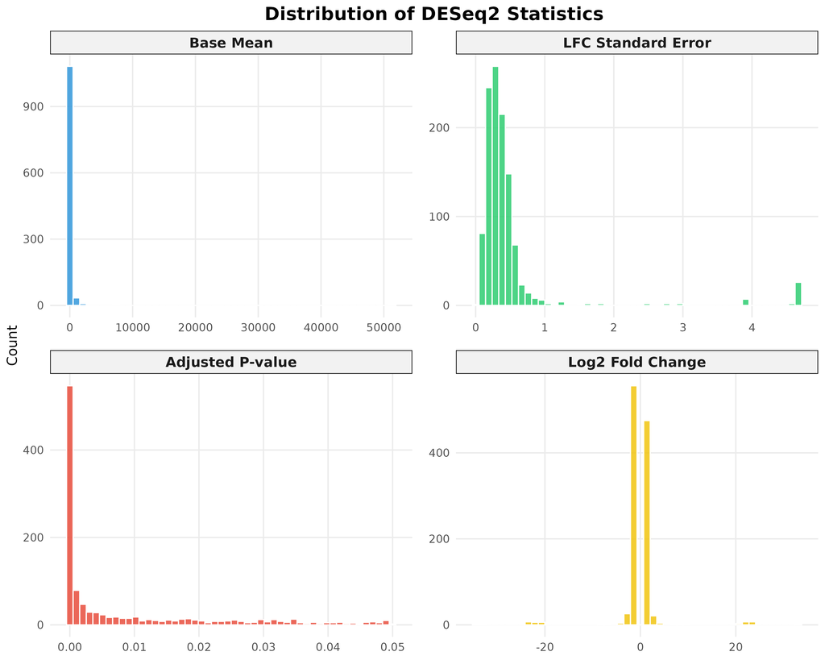

Count Distribution

```r
histogram_data <- filtered_results %>%
  select(baseMean, lfcSE, padj, log2FoldChange) %>%
  pivot_longer(
    cols = everything(),
    names_to = "metric",
    values_to = "value"
  ) %>%
  # Convert metric to a factor with a specific order
  mutate(metric = factor(metric, levels = c("baseMean", "lfcSE", "padj", "log2FoldChange"),
                         labels = c("Base Mean", "LFC Standard Error",
                                   "Adjusted P-value", "Log2 Fold Change")))

# Create a function to set appropriate limits for each metric
get_limits <- function(metric_name) {
  switch(as.character(metric_name),
         "Base Mean" = c(0, 500),
         "LFC Standard Error" = c(0, 2),
         "Adjusted P-value" = c(0, P_VALUE_FILTER),
         "Log2 Fold Change" = c(-5, 5))
}

# Create a nice color palette
histogram_colors <- c("Base Mean" = "#3498db",
                      "LFC Standard Error" = "#2ecc71",
                      "Adjusted P-value" = "#e74c3c",
                      "Log2 Fold Change" = "#f1c40f")

# Create faceted plot with different x-axis limits for each facet
faceted_plot <- ggplot(histogram_data, aes(x = value, fill = metric)) +
  geom_histogram(bins = 50, color = "white", alpha = 0.85) +
  facet_wrap(~ metric, scales = "free", ncol = 2) +
  scale_fill_manual(values = histogram_colors) +
  labs(
    title = "Distribution of DESeq2 Statistics",
    x = NULL,  # x-axis label is redundant with facet titles
    y = "Count"
  ) +
  theme_minimal(base_size = 12) +
  theme(
    strip.background = element_rect(fill = "gray95"),
    strip.text = element_text(face = "bold", size = 12),
    plot.title = element_text(face = "bold", hjust = 0.5, size = 16),
    panel.grid.minor = element_blank(),
    panel.spacing = unit(1, "lines"),
    legend.position = "none"  # Hide the legend as it's redundant
  )

# Save high-resolution version
ggsave("results/counts_distributions.png", faceted_plot,
       width = 10, height = 8, dpi = 300)
```

### Distribution of tpm results

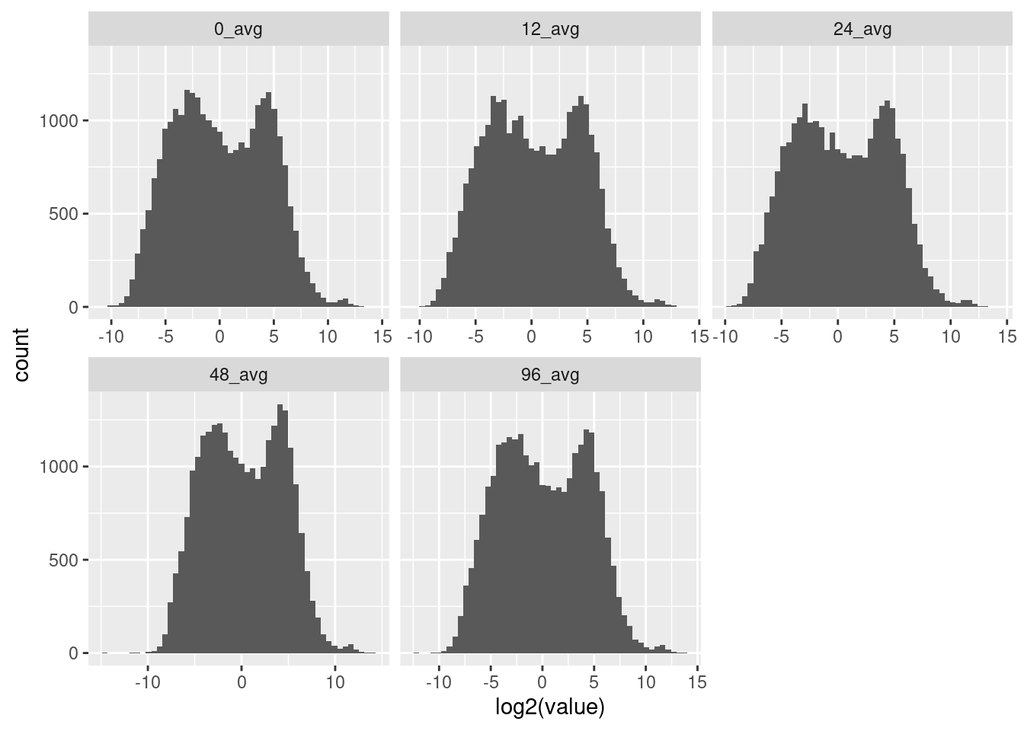

```r
# Make a distribution of TPM values in each time point - using facet-wrap
time_values <- names(avg_and_sd_values)[grep("avg", names(avg_and_sd_values))]
melt_tpm_df <- melt(avg_and_sd_values, measure.vars = time_values, value_name = "gene_id")
ggplot(melt_tpm_df, aes(x = log2(value))) +
  geom_histogram(bins = 50) +
  facet_wrap(~ variable, scales = "free_x")+
  theme("paperwhite")
```

### Volcano plots

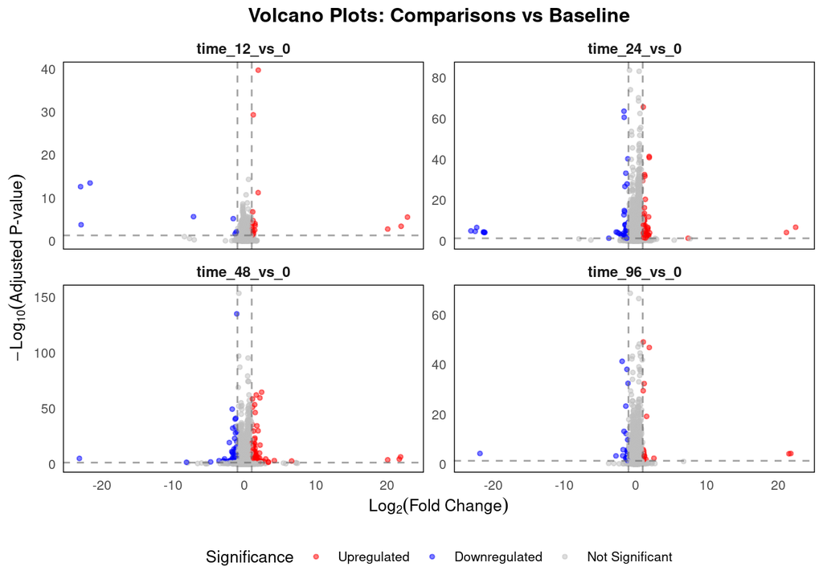

```r
# Pre-process results for volcano plot
filtered_results_vp <- results %>%
  mutate(
    negLog10Padj = -log10(padj),
     significance = case_when(
      padj < P_VALUE_FILTER & log2FoldChange > LOG2_FOLD_FILTER  ~ "Upregulated",
      padj < P_VALUE_FILTER & log2FoldChange < -LOG2_FOLD_FILTER ~ "Downregulated",
      TRUE                                                       ~ "Not Significant" ),
    significance = factor(significance, levels = c("Upregulated", "Downregulated", "Not Significant")),
    gene_label = if_else(significance != "Not Significant", gene_name, "")
    ) %>%
  filter(!is.na(padj) & !is.na(log2FoldChange))

# Define color map and theme
color_map <- c("Upregulated" = "red", "Downregulated" = "blue", "Not Significant" = "grey")
common_volcano_theme <- theme_minimal(base_size = 10) +
  theme(
    legend.position = "bottom",
    plot.title = element_text(hjust = 0.5, face = "bold", size = rel(1.2)),
    strip.text = element_text(face = "bold", size=rel(0.9)), # Style facet titles
    panel.grid.major = element_blank(),
    panel.grid.minor = element_blank(),
    panel.border = element_rect(color = "black", fill = NA, size = 0.5)
  )

# Filter Baseline Comparisons
baseline_comparisons <- c("time_12_vs_0", "time_24_vs_0", "time_48_vs_0", "time_96_vs_0")
filtered_results_vp_baseline<- filtered_results_vp %>%
  filter(comparison %in% baseline_comparisons) %>%
  mutate(comparison = factor(comparison, levels = baseline_comparisons))

# Plot Baseline Comparisons
plot_baseline <- ggplot(
    filtered_results_vp_baseline,
    aes(x = log2FoldChange, y = negLog10Padj, color = significance, label = gene_label)
    ) +
  geom_point(alpha = 0.5, size = 1.0) +
  scale_color_manual(values = color_map, name = "Significance") +
  geom_vline(xintercept = c(-LOG2_FOLD_FILTER, LOG2_FOLD_FILTER), lty = "dashed", color = "grey40", alpha=0.6) +
  geom_hline(yintercept = -log10(P_VALUE_FILTER), lty = "dashed", color = "grey40", alpha=0.6) +
  # Facet into a 2x2 grid
  facet_wrap(~ comparison, ncol = 2, scales = "free_y") +
  labs(
    title = "Volcano Plots: Comparisons vs Baseline",
    x = expression(Log[2]("Fold Change")),
    y = expression(-Log[10]("Adjusted P-value"))
  ) +
  common_volcano_theme +
  coord_cartesian(ylim = c(0, NA))
print(plot_baseline)
```

```r
ggsave("results/volcano_baseline.png", width = 20, height = 12)

#  Filter Time Series Comparisons
timeseries_comparisons <- c("time_12_vs_0", "time_24_vs_12", "time_48_vs_24", "time_96_vs_48")
filtered_results_vp_timeseries <- filtered_results_vp %>%
  filter(comparison %in% timeseries_comparisons) %>%
  # Ensure 'comparison' factor levels are only those present, in the desired order
  mutate(comparison = factor(comparison, levels = timeseries_comparisons))

# Plot Time Series Comparisons
plot_timeseries <- ggplot(
    filtered_results_vp_timeseries,
    aes(x = log2FoldChange, y = negLog10Padj, color = significance, label = gene_label)
    ) +
  geom_point(alpha = 0.5, size = 1.0) +
  scale_color_manual(values = color_map, name = "Significance") +
  geom_vline(xintercept = c(-LOG2_FOLD_FILTER, LOG2_FOLD_FILTER), lty = "dashed", color = "grey40", alpha=0.6) +
  geom_hline(yintercept = -log10(P_VALUE_FILTER), lty = "dashed", color = "grey40", alpha=0.6) +
  # Facet into a 2x2 grid
  facet_wrap(~ comparison, ncol = 2, scales = "free_y") +
  labs(
    title = "Volcano Plots: Sequential Time Comparisons",
    x = expression(Log[2]("Fold Change")),
    y = expression(-Log[10]("Adjusted P-value"))
  ) +
  common_volcano_theme
  coord_cartesian(ylim = c(0, NA))
```

[output not shown]

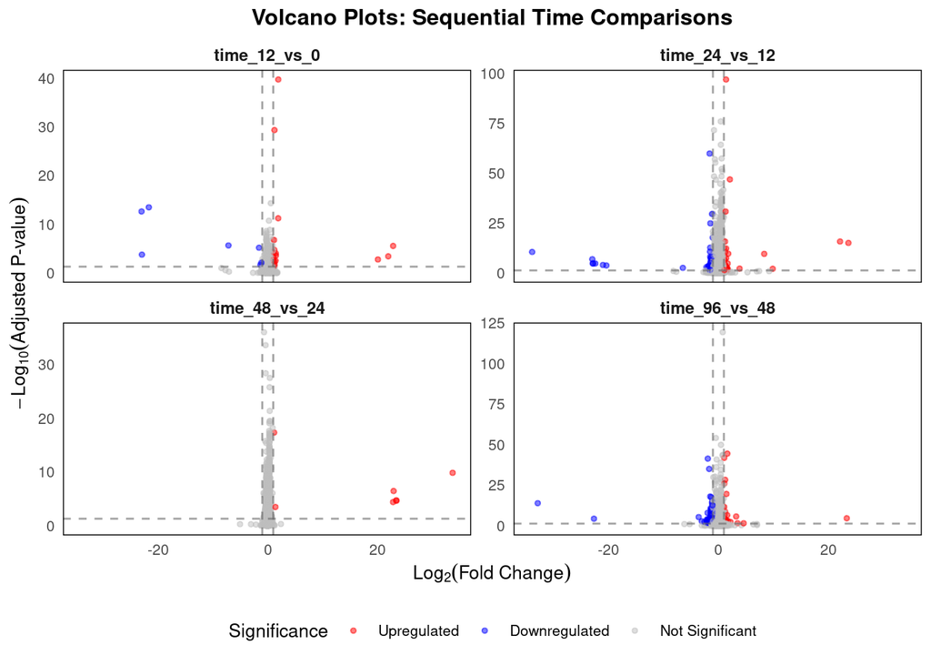

```r
print(plot_timeseries)
```

```r
ggsave("results/volcano_timeseries.png", width = 20, height = 12)
```